# MLpreTest

### **Machine Learning Prerequisite Test**

*Question 1*

Answer : We have two matrices of the dimensions (n,k) and (k,m). The resultant matrix will have dimensions (n,m).

Now, k is the number of columns in first matrix and number of rows in the second matrix. Thus, every entry will require k multiplications each. Now, we have entries across n rows and m columns. Thus, the total number of multiplications involved in multiplying the two matrices would be nkm.

Similarily, for addition we need (k-1) additions for a single entry. Now, there are (nxm) elements in this matrix of size (n,m). Thus, we need nxmx(k-1) additions for matrix multiplication.

*Question 2*

Answer: Let's analyze the time taken for matrix multiplication by list of lists and numpy with the help of an example.

Let matrix M1 be of the size (3,2) and M2 be of the size (2,4).

Now M1 = [[3,4], [2,7], [5,6]]

and M2 = [[1,7,1,1], [2,2,9,2]]

```python
#matrix multiplication using list in list

import time

#given matrices
M1 = [[3,4],
      [2,7],
      [5,6]]

M2 = [[1,7,1,1],
      [2,2,9,2]]

#empty matrix for storing the multiplication of both the matrices
#since size of M1 is (3,2) and size of M2 is (2,4), the size of multiplication matrix will be (3,4)

M3 = []

start1 = time.time()

for i in range(3):
  emp = []
  for j in range(4):
    total = 0
    for k in range(2):
      total = total + (M1[i][k] * M2[k][j])
    emp.append(total)
  M3.append(emp)

stop1 = time.time()

print (M3)
total_time1 = stop1 - start1
print("Time taken : ", total_time1)
```

```
[[11, 29, 39, 11], [16, 28, 65, 16], [17, 47, 59, 17]]
Time taken :  0.00023746490478515625
```

```python
#matrix multiplication using numpy
import numpy as np
M1 = np.array([[3,4],
               [2,7],
               [5,6]])

M2 = np.array([[1,7,1,1],
               [2,2,9,2]])

#calculating dot product of both the arrays
start2 = time.time()
M3 = np.dot(M1,M2)
stop2 = time.time()

print(M3)
total_time2 = stop2 - start2
print("Time Taken : ", total_time2)
```

```
[[11 29 39 11]
 [16 28 65 16]
 [17 47 59 17]]
Time Taken :  0.0001723766326904297
```

Question 3

Answer : Finding the highest element in the array has a time complexity of O(n) and finding the second highest element will have a time complexity of O(2n) i.e. O(n). Similarily, using the same approach finding the median of the array will take a time of O(n^2) i.e. O(n^2).

Thus, let us implement this with the help of a code

```python
import numpy as np
import time

arr = np.random.randint(0,9,size=9)
print(arr)

#median using np.median
start1 = time.time()
x = np.median(arr)
stop1 = time.time()
print('The median using numpy.median is',x, 'and the time taken is',(stop1-start1))

#median using a function
def give_median(arr):
  sorted_array = np.sort(arr)
  n = len(arr)
  if (n%2) == 0:
    a = sorted_array[n//2]
    b = sorted_array[(n//2)-1]
    c = (a+b)/2
    return c
  else:
    return sorted_array[n//2]

start2 = time.time()
y = give_median(arr)
stop2 = time.time()
print('The median using the above given function is',y, 'and the time taken is',(stop2-start2))
```

```
[1 8 3 5 1 7 4 0 4]
The median using numpy.median is 4.0 and the time taken is 0.00020551681518554688
The median using the above given function is 4 and the time taken is 0.0001304149627685547
```

Question 4

Answer : To find the gradient, let us find the partial derivative of the given function.

partial derivative of the function wrt x is

2xy + y^3*cos(x)

partial derivatice of function wrt y is

x^2 + 3*y^2*sin(x)

Thus, the gradient of the function is

(2xy + y^3*cos(x), x^2 + 3*y^2*sin(x))

Question 5

```python
#computing gradient using jax

import jax
import jax.numpy as jnp
from jax import grad
import math

#defining x and y
x0 = np.random.rand()
y0 = np.random.rand()

#converting to jax array for simplicity
x = jnp.array(x0)
y = jnp.array(y0)

#getting gradients using jax
dfx = grad(lambda x: (x**2 * y) + (y**3 * jnp.sin(x)))(x)
dfy = grad(lambda y: (x**2 * y) + (y**3 * jnp.sin(x)))(y)

#getting gradient using analytical solution
dfx_a = 2*x0*y0 + y0**3*math.cos(x0)
dfy_a = x0**2 + 3*y0**2*math.sin(x0)

print("jax sol : The gradient of the given function is (", dfx, "," ,dfy,")")
print("analytical sol : The gradient of the given function is (", dfx_a, "," ,dfy_a,")")
```

```
jax sol : The gradient of the given function is ( 0.2378428 , 0.89815265 )
analytical sol : The gradient of the given function is ( 0.23784282356490347 , 0.8981527171163322 )
```

Question 6

```python
import sympy as sp
import math
import numpy as np

#defining x and y
x,y = sp.symbols('x y')

#solution using sympy
dfx = sp.diff(((x**2)*y)+((y**3)*sp.sin(x)),x)
dfy = sp.diff(((x**2)*y)+((y**3)*sp.sin(x)),y)

#defining random values of x and y
xv = np.random.rand()
yv = np.random.rand()

#substituting the values in gradient function obtainted using sympy
dfx_v = dfx.subs({x:xv,y:yv})
dfy_v = dfy.subs({x:xv,y:yv})

#analytical solution
dfx_a1 = 2*xv*yv + yv**3*math.cos(xv)
dfy_a1 = xv**2 + 3*yv**2*math.sin(xv)

print("sympy solution : The gradient of the given function is (", dfx_v, "," ,dfy_v,")")
print("analytical sol : The gradient of the given function is (", dfx_a1, "," ,dfy_a1,")")
```

```
sympy solution : The gradient of the given function is ( 0.348055325250714 , 0.835446629908511 )
analytical sol : The gradient of the given function is ( 0.3480553252507141 , 0.8354466299085108 )
```

Question 7

```python
student_database = {

    2022 : {

      'Branch 1' : {

          1 : {

              'Name' : 'Sally', 'Marks' : {'Maths':100, 'English':70}

          },

          2 : {

              'Name' : 'Travice', 'Marks' : {'Maths':58, 'English':76}

          },

          3 : {

              'Name' : 'Taylor', 'Marks' : {'Maths':95, 'English':89}
          },
      },

      'Branch 2' : {

          4 : {

              'Name' : 'Andrew', 'Marks' : {'Economics':39, 'Mathematics':50}

          },

          5 : {

              'Name' : 'Helena', 'Marks' : {'Economics':93, 'Science':86}

          },
      },

    },

    2023 : {

      'Branch 1' : {

          6 : {

              'Name' : 'Anne', 'Marks' : {'History':77, 'Geography':64}

          },

          7 : {

              'Name' : 'Justin', 'Marks' : {'History':89, 'Geography':84}

          },

      },

      'Branch 2' : {

          8 : {

              'Name' : 'Hannah', 'Marks' : {'Biology':90, 'Chemistry':95}

          },

          9 : {

              'Name' : 'Joy', 'Marks' : {'Biology':76, 'Chemistry':76}

          },

          10 : {

              'Name' : 'Katherine', 'Marks' : {'Biology':57, 'Chemistry':91}
          },
      },

    },

    2024 : {

      'Branch 1' : {

          11 : {

              'Name' : 'Clay', 'Marks' : {'DSA':67, 'TOC':70}

          },

          12 : {

              'Name' : 'Jenson', 'Marks' : {'DSA':77, 'TOC':67}

          },

      },

      'Branch 2' : {

          13 : {

              'Name' : 'Bryce', 'Marks' : {'Philosophy':86, 'Psychology':96}

          },

          14 : {

              'Name' : 'Jenson', 'Marks' : {'Philosophy':87, 'Pyschology':67}

          },
      },

    },

    2025 : {

      'Branch 1' : {

          15 : {

              'Name' : 'Adam', 'Marks' : {'Physics':85, 'Chemistry':90}

          },

          16 : {

              'Name' : 'Trish', 'Marks' : {'Physics':77, 'Chemistry':76}

          },
      },

    },
}
```

Question 9

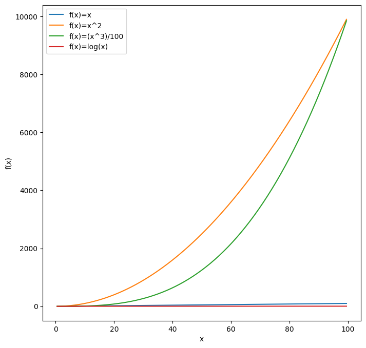

```python
import numpy as np
import matplotlib.pyplot as plt
import math

#defining domain
x = np.arange(0.5,100,0.5)

#defining functions
f1 = x
f2 = x**2
f3 = (x**3)/100
f6 = np.log(x)


#plotting
plt.figure(figsize = (8,8))
plt.plot(x,f1,label='f(x)=x')
plt.plot(x,f2,label='f(x)=x^2')
plt.plot(x,f3,label='f(x)=(x^3)/100')
plt.plot(x,f6,label='f(x)=log(x)')


plt.xlabel('x')
plt.ylabel('f(x)')
plt.legend()
plt.show()
```

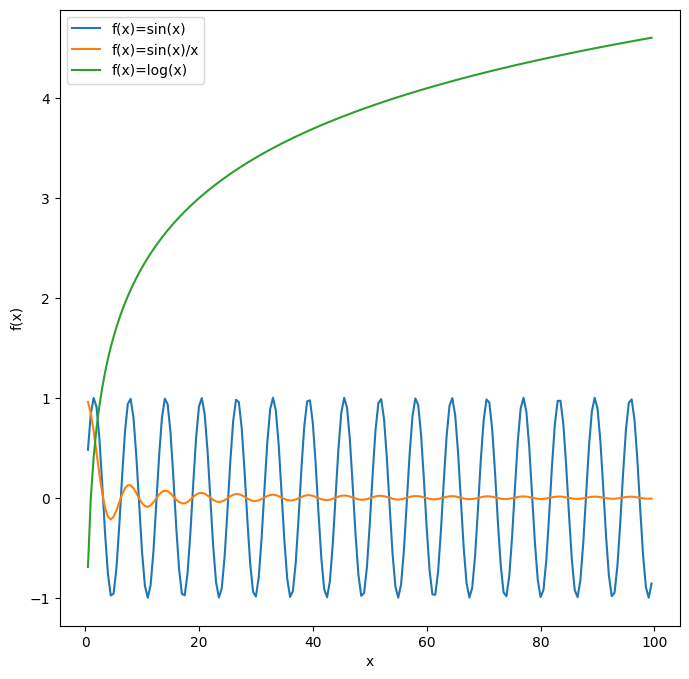

```python
import numpy as np
import matplotlib.pyplot as plt
import math

#defining domain
x = np.arange(0.5,100,0.5)

#defining functions

f4 = np.sin(x)
f5 = (np.sin(x))/x
f6 = np.log(x)

#plotting
plt.figure(figsize = (8,8))

plt.plot(x,f4,label='f(x)=sin(x)')
plt.plot(x,f5,label='f(x)=sin(x)/x')
plt.plot(x,f6,label='f(x)=log(x)')


plt.xlabel('x')
plt.ylabel('f(x)')
plt.legend()
plt.show()
```

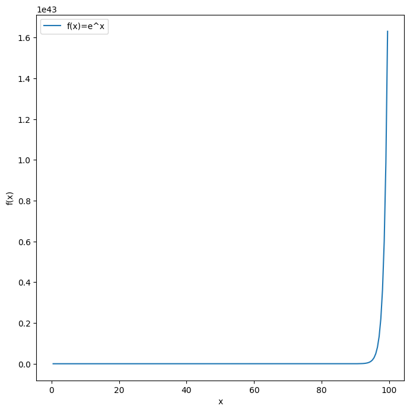

```python
import numpy as np
import matplotlib.pyplot as plt
import math

#defining domain
x = np.arange(0.5,100,0.5)

#defining functions

f7 = np.exp(x)

#plotting
plt.figure(figsize = (8,8))


plt.plot(x,f7,label='f(x)=e^x')


plt.xlabel('x')
plt.ylabel('f(x)')
plt.legend()
plt.show()
```

Question 10

```python
#generating a matrix of size (20,5) with random numbers in the range (1,2)
import numpy as np
import pandas as pd

M = np.random.uniform(1,2,size=(20,5))

#creating dataframe out of this matrix
df = pd.DataFrame(M,columns=['a','b','c','d','e'])

#creating the series of standard deviations
s_v = df.std()

x = s_v.idxmax()
y = s_v.max()

#creating the series of mean values
m_v = df.mean(axis=1)

p = m_v.idxmin()
q = m_v.min()

print('The column with highest standard deviation is',x, 'with a standard deviation of',y)
print('The row with lowest mean is',p, 'with a mean value of',q)
```

```
The column with highest standard deviation is e with a standard deviation of 0.2946644606628746
The row with lowest mean is 16 with a mean value of 1.2263779425735168
```

Question 11

```python
#adding column f which is sum of rest of the columns
df['f'] = df.sum(axis=1)

#creating another empty column g
df['g'] = ''

#checking and updating values
for i in range(20):
  if df.loc[i,'f'] < 8:
    df.loc[i,'g'] = 'LT8'
  else:
    df.loc[i,'g'] = 'GT8'

count = 0
for i in range(20):
  if df.loc[i,'g'] == 'LT8':
    count = count + 1
```

```python
print(df)
print('The number of rows where the value if LT8 are', count)
```

```
           a         b         c         d         e         f    g
0   1.318637  1.504374  1.474543  1.653251  1.321861  7.272667  LT8
1   1.575852  1.563420  1.221278  1.909530  1.051775  7.321855  LT8
2   1.376818  1.406720  1.545832  1.530627  1.341268  7.201265  LT8
3   1.183046  1.598521  1.440402  1.484600  1.251898  6.958467  LT8
4   1.523039  1.630857  1.019001  1.904728  1.219369  7.296993  LT8
5   1.706166  1.587636  1.430561  1.265286  1.871489  7.861139  LT8
6   1.961038  1.340763  1.728804  1.523871  1.436731  7.991208  LT8
7   1.949985  1.041315  1.780173  1.646514  1.066724  7.484711  LT8
8   1.079536  1.550464  1.953665  1.254165  1.947872  7.785703  LT8
9   1.229908  1.872535  1.456386  1.644039  1.811807  8.014676  GT8
10  1.211254  1.054500  1.174442  1.258067  1.870596  6.568859  LT8
11  1.473624  1.735900  1.084714  1.665708  1.890476  7.850422  LT8
12  1.372002  1.688774  1.009835  1.795141  1.372537  7.238290  LT8
13  1.403154  1.171507  1.698692  1.286065  1.274029  6.833447  LT8
14  1.744320  1.885385  1.578786  1.672433  1.497469  8.378393  GT8
15  1.407282  1.760630  1.483067  1.443842  1.519898  7.614719  LT8
16  1.011126  1.589129  1.178620  1.052973  1.300042  6.131890  LT8
17  1.038494  1.828090  1.483599  1.441996  1.097993  6.890173  LT8
18  1.803594  1.991607  1.753883  1.628605  1.142634  8.320323  GT8
19  1.239253  1.619230  1.162794  1.004477  1.560543  6.586297  LT8
The number of rows where the value if LT8 are 17
```

```python
s_l = df[df['g'] == 'LT8']['f'].std()
g_l = df[df['g'] == 'GT8']['f'].std()

print('Standard Deviation for LT8', s_l)
print('Standard Deviation for GT8', g_l)
```

```
Standard Deviation for LT8 0.5186385958221931
Standard Deviation for GT8 0.19539786634897527
```

Question 12

Answer : Broadcasting in numpy refers to performing arithmetic operations on arrays of different dimensions. One such example is as follows -

```python
#creating matrix with random numbers
M1 = np.random.uniform(size=(3,5))
a = [7]

#multiplying matrix 1 with another 1D matrix
ans = M1*a

print(M1)
print(ans)
```

```
[[0.32877909 0.76740489 0.57628531 0.29223552 0.50321415]
 [0.27668822 0.38357912 0.23608286 0.49238032 0.03269915]
 [0.5581195  0.56747759 0.80104318 0.98237303 0.01351288]]
[[2.30145362 5.37183423 4.03399715 2.04564867 3.52249907]
 [1.93681754 2.68505384 1.65258003 3.44666223 0.22889404]
 [3.90683647 3.97234311 5.60730228 6.87661123 0.09459016]]
```

Question 13

```python
#generating a 1D numpy array
arr = np.random.randint(0,10,size=7)
print('The array is',arr)

def find_argmin(arr):
  ind = 0
  min = arr[0]
  for i in range(len(arr)):
    if arr[i] < min:
      min = arr[i]
      ind = i

  return ind


x = find_argmin(arr)
print('by creating a function',x)

y = np.argmin(arr)
print('by using argmin function from numpy library', y)
print('Thus, it is verified that our function works correctly!')
```

```
The array is [9 0 6 6 4 1 4]
by creating a function 1
by using argmin function from numpy library 1
Thus, it is verified that our function works correctly!
```